# 02 — Exploratory Data Analysis (EDA)

### 3.4 Rolling Correlation

To study how the comovement between IBEX 35 and S&P 500 evolves over time, we compute a **rolling (moving-window) correlation** that allows us to capture periods of increasing integration, divergence, or structural breaks.

The rolling correlation with ¨k¨ window size is defined as:

$$ \rho_{t}^{(k)} = \frac{ \sum_{i=t-k+1}^{t} (x_i - \bar{x})(y_i - \bar{y}) }{ \sqrt{ \sum_{i=t-k+1}^{t}(x_i - \bar{x})^2 } \sqrt{ \sum_{i=t-k+1}^{t}(y_i - \bar{y})^2 } } $$

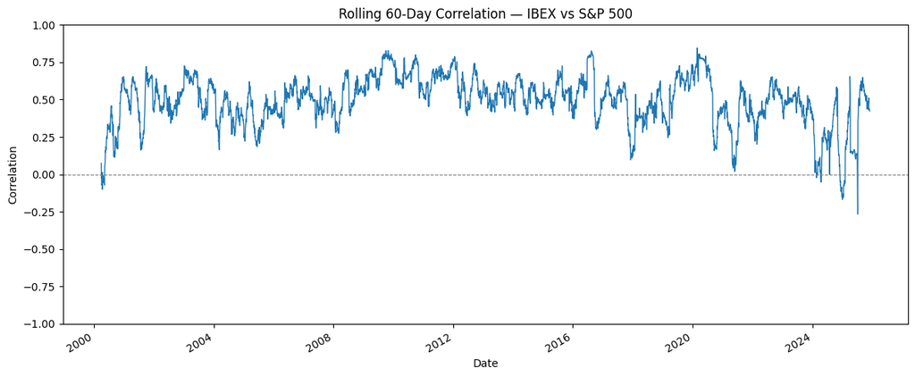

```python
# 3.4 CORRELATION DYNAMICS

window = 60  # 60-day rolling window
rolling_corr = returns["IBEX_ret"].rolling(window).corr(returns["SPX_ret"])

fig, ax = plt.subplots(figsize=(12, 5))
rolling_corr.plot(ax=ax, color="tab:blue", linewidth=1)
ax.set_title(f"Rolling {window}-Day Correlation — IBEX vs S&P 500")
ax.set_ylabel("Correlation")
ax.set_ylim(-1, 1)
plt.axhline(0, color="gray", linestyle="--", linewidth=0.8)
plt.tight_layout()
plt.show()

# SAVE FIGURE
fig.savefig(EDA_DIR / "eda_correlation.png", dpi=300, bbox_inches="tight")
```

### Technical Summary of Visual Explorations

This section comprises four diagnostic visualisations designed to describe the behaviour of returns, prices, volatility, and correlations over time.  
Each plot serves a technical purpose within the exploratory stage.

**1. Daily Log Returns** displays day-to-day logarithmic returns for both indices to visualize short-term risk dynamics and detect volatility clustering. Here I identify non-constant variance and potential periods of heteroscedasticity which could be relevant for later ARCH–GARCH modelling.

**2. Price Trajectories** shows the level evolution of both indices since 2000, without normalisation. As each index operates on a different numerical base (IBEX ≈ 10,000; S&P 500 ≈ 2,000) prices are not directly comparable.  
It should also be mentioned that it excludes dividend reinvestment, so it just reflects price-only performance.

**3. Rolling Volatility (20-Day Annualised)** the plots of the moving standard deviation of daily returns provide a visual confirmation of heteroscedasticity, supporting the need for GARCH-type variance modelling.

**4. Rolling Correlation (60-Day)** the rolling Pearson correlation between both return series shows us the co-movement and cross-market integration, which work as a clue about the tests of dynamic dependence and diversification efficiency.

These diagnostics characterise the statistical properties of the time series (variance non-stationarity, volatility persistence, and dynamic correlation) which is the base of the econometric tests and modeling that follow.

## 4. Statistical Testing

This section validates the statistical properties observed during the visual exploration through econometric tests. While plots revealed potential non-stationarity, volatility clustering, and non-normality, here we test these features using three standard diagnostics.

The objective is to confirm whether the data meet the assumptions required for time-series modeling and to determine which models (ARIMA, GARCH, etc.) are appropriate for the next stages.

We’ll perform the following tests:

1. **ADF (Augmented Dickey–Fuller)** tests for stationarity of the return series.
2. **ARCH–LM (Engle’s Lagrange Multiplier)** tests for conditional heteroskedasticity (ARCH effects).
3. **Jarque–Bera** tests whether the distribution of returns departs from normality.

Combined, these tests offer statistical proof of the dynamics of both indices' means and variances.

```python
from statsmodels.tsa.stattools import adfuller

# 4.1 ADF
def adf_test(series, name="Series"):
    result = adfuller(series, autolag="AIC")

    print(f"\nADF Test: {name}")
    print(f"ADF Statistic: {result[0]:.4f}")
    print(f"p-value:        {result[1]:.4f}")

    for key, value in result[4].items():
        print(f"Critical Value {key}: {value:.4f}")

    print()

# Run test
adf_test(returns["IBEX_ret"], "IBEX Returns")
adf_test(returns["SPX_ret"], "S&P 500 Returns")
```

```
ADF Test: IBEX Returns
ADF Statistic: -23.6989
p-value:        0.0000
Critical Value 1%: -3.4314
Critical Value 5%: -2.8620
Critical Value 10%: -2.5670


ADF Test: S&P 500 Returns
ADF Statistic: -18.2582
p-value:        0.0000
Critical Value 1%: -3.4314
Critical Value 5%: -2.8620
Critical Value 10%: -2.5670
```

```python
from statsmodels.stats.diagnostic import het_arch

# 4.2 ARCH–LM
def arch_lm_test(series, name="Series", lags=12):
    lm_stat, lm_pval, f_stat, f_pval = het_arch(series, nlags=lags)

    print(f"\nARCH–LM Test: {name}")
    print(f"LM Statistic: {lm_stat:.4f}")
    print(f"p-value (LM): {lm_pval:.4f}")
    print(f"F Statistic:  {f_stat:.4f}")
    print(f"p-value (F):  {f_pval:.4f}")
    print()

# Run test
arch_lm_test(returns["IBEX_ret"], "IBEX Returns")
arch_lm_test(returns["SPX_ret"], "S&P 500 Returns")
```

```
ARCH–LM Test: IBEX Returns
LM Statistic: 728.7633
p-value (LM): 0.0000
F Statistic:  68.3829
p-value (F):  0.0000


ARCH–LM Test: S&P 500 Returns
LM Statistic: 1736.4157
p-value (LM): 0.0000
F Statistic:  198.0723
p-value (F):  0.0000
```

```python
from scipy.stats import jarque_bera

# 4.3 JARQUE–BERA
def jarque_bera_test(series, name="Series"):
    jb_stat, jb_pval = jarque_bera(series)

    print(f"\nJarque–Bera Test: {name}")
    print(f"JB Statistic: {jb_stat:.4f}")
    print(f"p-value:       {jb_pval:.4f}")
    print()

# Run test
jarque_bera_test(returns["IBEX_ret"], "IBEX Returns")
jarque_bera_test(returns["SPX_ret"], "S&P 500 Returns")
```

```
Jarque–Bera Test: IBEX Returns
JB Statistic: 17208.0331
p-value:       0.0000


Jarque–Bera Test: S&P 500 Returns
JB Statistic: 29699.3712
p-value:       0.0000
```

### 4.4 Summary of Statistical Tests

The statistical diagnostics applied in this section validate the key assumptions of financial time series analysis.

**4.1 ADF (Augmented Dickey–Fuller Test):** It has been chosen because it confirms that both the IBEX and S&P 500 return series are stationary, meaning their statistical properties —mean and variance— remain stable over time. A p-value below 0.05 indicates rejection of the null hypothesis of a unit root, implying that the series does not follow a random walk and lacks a stochastic trend. In other words, shocks to the series are temporary, and values tend to revert toward a long-term mean, making the data suitable for econometric modelling. It is important to figure out because some predictive and volatility models, such as ARIMA or GARCH assume that the return process is stationary.

**4.2 ARCH–LM (Engle’s Lagrange Multiplier Test):** The use of ARCH–LM is to test whether the error variance changes over time. A p-value below 0.05 indicates conditional heteroscedasticity, a defining feature of financial return series. This means that return variance is not constant and that ARCH effects are present — periods of high volatility tend to cluster together. Such behaviour violates the constant-variance assumption of classical models and supports the use of conditional variance models such as GARCH, or EGARCH, which can capture time-varying volatility.

**4.3 Jarque–Bera Test:** Here, the Jarque–Bera has been performed in order to test shows that return distributions deviate significantly from normality, exhibiting fat tails (high kurtosis) and asymmetry (skewness). Statistically, this indicates that extreme market movements occur more frequently than predicted by a normal distribution, so subsequent models should incorporate non-Gaussian innovations, such as the Student’s t or Generalised Error Distribution, to better represent tail risk and heavy-tailed behaviour.

To sum up, the results confirm that return series are stationary, heteroskedastic, and non-normal, because of this, the next modelling stages must include conditional variance models with heavy-tailed distributions in order to capture the empirical dynamics of financial markets.

## 5. Analytical Insights

The exploratory and statistical analyses jointly describe the structural behaviour of the IBEX 35 and S&P 500 indices over the 2000–2025 period, confirming that both markets exhibit the typical properties of financial return series: stationarity, conditional heteroskedasticity, and non-normality.

1. Market Structure and Dynamics Price trajectories show long-term growth punctuated by volatility spikes during major global crises (2008, 2011, 2020, 2022). The IBEX 35 displays higher annualised volatility (≈22%) and slower post-crisis recoveries, while the S&P 500 maintains lower volatility (≈19%) and stronger resilience, reflecting greater depth and diversification. Despite these structural differences, both indices exhibit synchronous stress patterns and similar cyclical behaviour.
2. Return Distribution and Volatility Behaviour Daily returns fluctuate around zero with volatility clustering, confirming the ARCH effects identified in statistical tests. Calm periods alternate with sharp turbulence, indicating the necessity of variance models. Also, the presence of fat tails increases the probability of extreme movements, so we require heavy-tailed innovation distributions (e.g., Student-t) in the following modelling.
3. Cross-Market Correlation The average correlation between daily returns is approximately 0.50, signalling moderate co-movement. It is important to remark that this dependence intensifies during crisis periods ( because of the contagion effect) and weakens in stable phases.
4. Modelling Implications This supports a two-layer econometric modelling framework:
- The mean equation, return dynamics, will be estimated through ARIMA and Prophet models to evaluate short-term predictability.
- The variance equation, risk dynamics, will be modelled using EGARCH, capturing asymmetry and leverage effects. Derived from these conditional volatility estimates, Value at Risk (VaR) and Expected Shortfall (ES) will provide quantitative measures of downside risk.

In conclusion, both markets demonstrate non-constant volatility, heavy-tailed distributions, and moderate correlation—empirical features that justify the use of modern econometric models capable of capturing non-linear and time-dependent risk dynamics.

Next Notebook focuses on modelling the mean equation through ARIMA and Prophet, comparing their predictive accuracy and validating their residual structure.

## 6. Power BI Export Summary:

Generate a consolidated dataset (returns_summary.csv) containing log returns, rolling volatility, and correlations, prepared for integration into a future interactive dashboard that visualizes market dynamics between the IBEX 35 and the S&P 500.

```python
# 6. COMPUTE ROLLING VOLATILITY AND CORRELATION SUMMARY
returns_summary_df = (
    returns.assign(
        IBEX_vol = returns["IBEX_ret"].rolling(30).std() * (252 ** 0.5),
        SPX_vol  = returns["SPX_ret"].rolling(30).std() * (252 ** 0.5),
        corr_rolling = returns["IBEX_ret"].rolling(60).corr(returns["SPX_ret"])
    )
    .dropna()
)

returns_summary_df.head()
```

| Date | IBEX_ret | SPX_ret | IBEX_vol | SPX_vol | corr_rolling |
| --- | --- | --- | --- | --- | --- |
| 2000-03-30 | -0.021337 | -0.013750 | 0.197511 | 0.261945 | 0.075082 |
| 2000-03-31 | 0.008549 | 0.007139 | 0.197947 | 0.262244 | -0.024361 |
| 2000-04-03 | -0.021049 | 0.004919 | 0.205688 | 0.242402 | -0.029568 |
| 2000-04-04 | -0.008784 | -0.007492 | 0.196154 | 0.244558 | -0.070011 |
| 2000-04-05 | -0.018259 | -0.004936 | 0.191886 | 0.245545 | -0.066131 |

```python
# FINAL EXPORTS FOR POWER BI (EDA)

import sys
from pathlib import Path

ROOT = Path.cwd().parent
sys.path.append(str(ROOT / "src"))

from export import export

# Export all EDA datasets
export(returns, "returns_clean")
export(vol, "volatility_simple")
export(returns_summary_df, "returns_summary")

print("EDA exports completed.")
```

```
[EXPORT] returns_clean.csv saved to /mnt/c/Users/apalo/Desktop/forescasting_results/returns_clean.csv
[EXPORT] volatility_simple.csv saved to /mnt/c/Users/apalo/Desktop/forescasting_results/volatility_simple.csv
[EXPORT] returns_summary.csv saved to /mnt/c/Users/apalo/Desktop/forescasting_results/returns_summary.csv
EDA exports completed.
```